# Generative Adversarial Networks (GANs) using CIFAR-10

It explains the theory of **Generative Adversarial Networks (GANs)** and then shows how to implement a simple GAN on the **CIFAR-10** dataset using **PyTorch**.

## Lab Objectives

After completing this lab, students will be able to:

1. Understand the basic idea of generative models.
2. Explain the working principles of a GAN.
3. Describe the roles of the **Generator** and **Discriminator**.
4. Understand the mathematical objective function of GAN.
5. Implement and train a GAN using the CIFAR-10 dataset.
6. Visualize generated synthetic images.
7. Analyze GAN training challenges such as instability and mode collapse.

## Software and Tools

- Google Colab
- Python
- PyTorch
- Matplotlib
- Torchvision

## Dataset

We will use the **CIFAR-10** dataset.

CIFAR-10 contains:

- 60,000 color images
- 10 classes
- image size = **32 x 32**
- 3 color channels (RGB)

The 10 classes are:

1. Airplane
2. Automobile
3. Bird
4. Cat
5. Deer
6. Dog
7. Frog
8. Horse
9. Ship
10. Truck

# 1. Introduction to Generative Models

Most traditional machine learning models are **discriminative**.  
That means they learn how to distinguish between classes.

For example:

- A classifier learns whether an image is a **cat** or a **dog**.
- It learns a mapping from input (x) to label (y).

A **generative model**, on the other hand, tries to learn the **data distribution** itself.

Instead of answering:

> "Is this image real or fake?"

it tries to answer:

> "Can I create a new image that looks like the training data?"

Examples of generative models:

- GAN
- Variational Autoencoder (VAE)
- Diffusion models

In this lab, we focus on **GANs**.

# 2. What is a GAN?

A **Generative Adversarial Network (GAN)** is a framework introduced by Ian Goodfellow and colleagues in 2014.

A GAN consists of **two neural networks**:

## 2.1 Generator (G)

The Generator:

- takes a random noise vector (z) as input
- produces a synthetic image (G(z))
- tries to generate images that look real

## 2.2 Discriminator (D)

The Discriminator:

- takes an image as input
- outputs a probability between 0 and 1
- predicts whether the image is **real** or **fake**

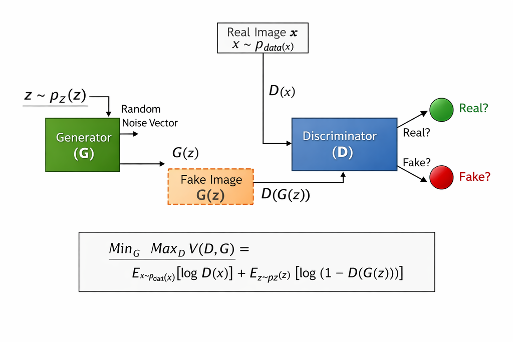

## 2.3 Adversarial Idea

The Generator and Discriminator are trained in a competitive way:

- The **Generator** tries to fool the Discriminator.
- The **Discriminator** tries to correctly classify real and fake images.

This creates a two-player minimax game.

### Intuition

- If the Discriminator becomes stronger, it can detect fake images better.
- If the Generator becomes stronger, it can create more realistic images.
- Over time, both networks improve.

This adversarial process is the core idea of GAN.

# 3. Mathematical Formulation of GAN

The original GAN objective function is:

$$ \min_G \max_D V(D,G) = \mathbb{E}_{x \sim p_{data}(x)}[\log D(x)] + \mathbb{E}_{z \sim p_z(z)}[\log(1 - D(G(z)))] $$

Where:

- $x \sim p_{data}(x)$ means a real sample from the dataset
- $z \sim p_z(z)$ means a random noise vector
- $G(z)$ is the fake image generated from noise
- $D(x)$ is the probability that $x$ is real
- $D(G(z))$ is the probability that a generated image is real

## 3.1 Objective of the Discriminator

The Discriminator wants to:

- maximize (D(x)) for real images
- minimize (D(G(z))) for fake images

So the Discriminator tries to maximize:

$$ \log D(x) + \log(1 - D(G(z))) $$

That means:

- real images should be classified close to 1
- fake images should be classified close to 0

## 3.2 Objective of the Generator

The Generator wants to fool the Discriminator.

So the Generator tries to generate images such that:

$$ D(G(z)) \approx 1 $$

In practice, instead of minimizing $ \log(1 - D(G(z)))$, we often maximize:

$$ \log D(G(z)) $$

because it gives stronger gradients early in training.

## 3.3 Binary Cross-Entropy Loss

Since the Discriminator performs a binary classification task, we use **Binary Cross-Entropy (BCE)** loss.

The BCE loss is:

$$ L = - \left[ y \log(\hat{y}) + (1-y)\log(1-\hat{y}) \right] $$

Where:

- $y$ is the true label
- $\hat{y}$ is the predicted probability

For the Discriminator:

- real image label = 1
- fake image label = 0

For the Generator:

- fake images are assigned target label = 1 during Generator training
- this encourages the Generator to produce more realistic outputs

# 4. GAN Training Procedure

Each training iteration has two main steps.

## Step 1: Train the Discriminator

1. Take a batch of real images from CIFAR-10.
2. Assign label 1 to real images.
3. Generate fake images using the Generator.
4. Assign label 0 to fake images.
5. Compute the Discriminator loss on both real and fake images.
6. Update the Discriminator parameters.

## Step 2: Train the Generator

1. Generate a new batch of fake images.
2. Pass them through the Discriminator.
3. Pretend these fake images are real by assigning label 1.
4. Compute Generator loss.
5. Update Generator parameters.

## Why train separately?

The Discriminator and Generator have opposite goals.  
So they must be updated separately in each iteration.

# 5. Why CIFAR-10 is More Challenging than MNIST

MNIST contains simple grayscale digits of size 28 x 28.  
CIFAR-10 is more difficult because:

- it uses **RGB color images**
- the image content is more complex
- images have more texture and background variation
- classes are more diverse

So generating realistic CIFAR-10 images is harder than generating MNIST digits.

That is why this lab uses a **Deep Convolutional GAN (DCGAN-style)** model instead of a simple fully connected GAN.

```python
# 6. Import Required Libraries

import os
import math
import torch
import torch.nn as nn
import torch.optim as optim
import matplotlib.pyplot as plt
import numpy as np

from torch.utils.data import DataLoader
from torchvision import datasets, transforms
import torchvision.utils as vutils

print("PyTorch version:", torch.__version__)
```

```
PyTorch version: 2.10.0+cu128
```

```python
# 7. Set Device

device = torch.device("cuda" if torch.cuda.is_available() else "cpu")
print("Using device:", device)
```

```
Using device: cuda
```

```python
# 8. Hyperparameters

batch_size = 128
image_size = 32
channels = 3
latent_dim = 100
g_features = 64
d_features = 64
lr = 0.0002
beta1 = 0.5
epochs = 20
sample_dir = "cifar10_gan_samples"

os.makedirs(sample_dir, exist_ok=True)

print("Batch size:", batch_size)
print("Latent dimension:", latent_dim)
print("Epochs:", epochs)
```

```
Batch size: 128
Latent dimension: 100
Epochs: 20
```

# 6. Data Preprocessing

Before feeding images to the network, we transform them.

## Why normalization is needed?

The Generator uses **Tanh** activation in the output layer.  
Tanh gives output in the range:

$ [-1, 1] $

So the real images should also be normalized to the same range.

For CIFAR-10, we normalize each color channel using:

$ x' = \frac{x - 0.5}{0.5} $

This converts pixel values from ([0,1]) to ([-1,1]).

```python
# 9. Load CIFAR-10 Dataset

transform = transforms.Compose([
    transforms.ToTensor(),
    transforms.Normalize((0.5, 0.5, 0.5),
                         (0.5, 0.5, 0.5))
])

train_dataset = datasets.CIFAR10(
    root="./data",
    train=True,
    transform=transform,
    download=True
)

train_loader = DataLoader(
    train_dataset,
    batch_size=batch_size,
    shuffle=True,
    num_workers=2,
    pin_memory=True if torch.cuda.is_available() else False
)

classes = train_dataset.classes
print("Classes:", classes)
print("Number of training samples:", len(train_dataset))
```

```
Classes: ['airplane', 'automobile', 'bird', 'cat', 'deer', 'dog', 'frog', 'horse', 'ship', 'truck']
Number of training samples: 50000
```

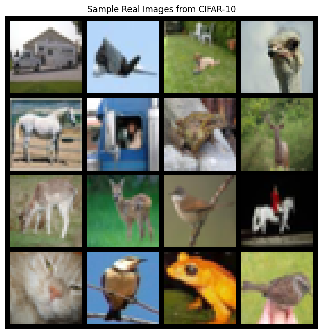

```
Example labels:
['truck', 'airplane', 'dog', 'bird', 'horse', 'truck', 'frog', 'deer', 'deer', 'deer', 'bird', 'horse', 'cat', 'bird', 'frog', 'bird']
```

```python
# 10. Show Some Real CIFAR-10 Images

real_images, real_labels = next(iter(train_loader))

# Unnormalize for display
display_images = real_images[:16] * 0.5 + 0.5

grid = vutils.make_grid(display_images, nrow=4, padding=2)

plt.figure(figsize=(8, 8))
plt.imshow(np.transpose(grid.numpy(), (1, 2, 0)))
plt.title("Sample Real Images from CIFAR-10")
plt.axis("off")
plt.show()

print("Example labels:")
print([classes[label] for label in real_labels[:16]])
```

# 7. DCGAN Architecture

For image generation, convolutional neural networks work better than fully connected networks.

In this lab:

- the **Generator** uses transposed convolutions to upsample noise into images
- the **Discriminator** uses convolutions to classify images as real or fake

## 7.1 Generator Flow

The Generator transforms:

$$ z \in \mathbb{R}^{100} \quad \rightarrow \quad \text{feature maps} \quad \rightarrow \quad 32 \times 32 \times 3 \text{ image} $$

Typical Generator blocks:

- ConvTranspose2d
- BatchNorm2d
- ReLU
- Tanh at the output

## 7.2 Discriminator Flow

The Discriminator transforms:

$$ 32 \times 32 \times 3 \text{ image} \quad \rightarrow \quad \text{feature extraction} \quad \rightarrow \quad \text{real/fake score} $$

Typical Discriminator blocks:

- Conv2d
- BatchNorm2d
- LeakyReLU
- Sigmoid at the output

```python
# 11. Weight Initialization Function

def weights_init(m):
    classname = m.__class__.__name__
    if classname.find("Conv") != -1:
        nn.init.normal_(m.weight.data, 0.0, 0.02)
    elif classname.find("BatchNorm") != -1:
        nn.init.normal_(m.weight.data, 1.0, 0.02)
        nn.init.constant_(m.bias.data, 0)
```

```python
# 12. Define the Generator

class Generator(nn.Module):
    def __init__(self, latent_dim, g_features, channels):
        super(Generator, self).__init__()
        self.net = nn.Sequential(
            # Input: N x latent_dim x 1 x 1
            nn.ConvTranspose2d(latent_dim, g_features * 4, kernel_size=4, stride=1, padding=0, bias=False),
            nn.BatchNorm2d(g_features * 4),
            nn.ReLU(True),

            # State: N x (g_features*4) x 4 x 4
            nn.ConvTranspose2d(g_features * 4, g_features * 2, kernel_size=4, stride=2, padding=1, bias=False),
            nn.BatchNorm2d(g_features * 2),
            nn.ReLU(True),

            # State: N x (g_features*2) x 8 x 8
            nn.ConvTranspose2d(g_features * 2, g_features, kernel_size=4, stride=2, padding=1, bias=False),
            nn.BatchNorm2d(g_features),
            nn.ReLU(True),

            # State: N x g_features x 16 x 16
            nn.ConvTranspose2d(g_features, channels, kernel_size=4, stride=2, padding=1, bias=False),
            nn.Tanh()

            # Output: N x 3 x 32 x 32
        )

    def forward(self, x):
        return self.net(x)
```

```python
# 13. Define the Discriminator

class Discriminator(nn.Module):
    def __init__(self, channels, d_features):
        super(Discriminator, self).__init__()
        self.net = nn.Sequential(
            # Input: N x 3 x 32 x 32
            nn.Conv2d(channels, d_features, kernel_size=4, stride=2, padding=1, bias=False),
            nn.LeakyReLU(0.2, inplace=True),

            # State: N x d_features x 16 x 16
            nn.Conv2d(d_features, d_features * 2, kernel_size=4, stride=2, padding=1, bias=False),
            nn.BatchNorm2d(d_features * 2),
            nn.LeakyReLU(0.2, inplace=True),

            # State: N x (d_features*2) x 8 x 8
            nn.Conv2d(d_features * 2, d_features * 4, kernel_size=4, stride=2, padding=1, bias=False),
            nn.BatchNorm2d(d_features * 4),
            nn.LeakyReLU(0.2, inplace=True),

            # State: N x (d_features*4) x 4 x 4
            nn.Conv2d(d_features * 4, 1, kernel_size=4, stride=1, padding=0, bias=False),
            nn.Sigmoid()

            # Output: N x 1 x 1 x 1
        )

    def forward(self, x):
        return self.net(x).view(-1, 1)
```

```python
# 14. Create Model Instances

generator = Generator(latent_dim, g_features, channels).to(device)
discriminator = Discriminator(channels, d_features).to(device)

generator.apply(weights_init)
discriminator.apply(weights_init)

print(generator)
print()
print(discriminator)
```

```
Generator(
  (net): Sequential(
    (0): ConvTranspose2d(100, 256, kernel_size=(4, 4), stride=(1, 1), bias=False)
    (1): BatchNorm2d(256, eps=1e-05, momentum=0.1, affine=True, track_running_stats=True)
    (2): ReLU(inplace=True)
    (3): ConvTranspose2d(256, 128, kernel_size=(4, 4), stride=(2, 2), padding=(1, 1), bias=False)
    (4): BatchNorm2d(128, eps=1e-05, momentum=0.1, affine=True, track_running_stats=True)
    (5): ReLU(inplace=True)
    (6): ConvTranspose2d(128, 64, kernel_size=(4, 4), stride=(2, 2), padding=(1, 1), bias=False)
    (7): BatchNorm2d(64, eps=1e-05, momentum=0.1, affine=True, track_running_stats=True)
    (8): ReLU(inplace=True)
    (9): ConvTranspose2d(64, 3, kernel_size=(4, 4), stride=(2, 2), padding=(1, 1), bias=False)
    (10): Tanh()
  )
)

Discriminator(
  (net): Sequential(
    (0): Conv2d(3, 64, kernel_size=(4, 4), stride=(2, 2), padding=(1, 1), bias=False)
    (1): LeakyReLU(negative_slope=0.2, inplace=True)
    (2): Conv2d(64, 128, kernel_size=(4, 4), stride=(2, 2), padding=(1, 1), bias=False)
    (3): BatchNorm2d(128, eps=1e-05, momentum=0.1, affine=True, track_running_stats=True)
    (4): LeakyReLU(negative_slope=0.2, inplace=True)
    (5): Conv2d(128, 256, kernel_size=(4, 4), stride=(2, 2), padding=(1, 1), bias=False)
    (6): BatchNorm2d(256, eps=1e-05, momentum=0.1, affine=True, track_running_stats=True)
    (7): LeakyReLU(negative_slope=0.2, inplace=True)
    (8): Conv2d(256, 1, kernel_size=(4, 4), stride=(1, 1), bias=False)
    (9): Sigmoid()
  )
)
```

# 8. Loss Function and Optimizers

We use **Binary Cross-Entropy Loss**:

$$ L = - \left[ y \log(\hat{y}) + (1-y)\log(1-\hat{y}) \right] $$

### For the Discriminator

The total loss is:

$$ L_D = L_{real} + L_{fake} $$

Where:

- $L_{real}$ is the loss on real images
- $L_{fake}$ is the loss on fake images

### For the Generator

The Generator loss is:

$$ L_G = BCE(D(G(z)), 1) $$

because the Generator wants fake images to be classified as real.

## Why Adam optimizer?

Adam is commonly used in GAN training because it adapts learning rates and works well in practice.

In DCGAN, a common choice is:

- learning rate = 0.0002
- $\beta_1 = 0.5$

```python
# 15. Loss Function and Optimizers

criterion = nn.BCELoss()

optimizer_G = optim.Adam(generator.parameters(), lr=lr, betas=(beta1, 0.999))
optimizer_D = optim.Adam(discriminator.parameters(), lr=lr, betas=(beta1, 0.999))
```

```python
# 16. Utility Function to Display Generated Images

def show_generated_images(generator, epoch, latent_dim, device, num_images=16):
    generator.eval()
    with torch.no_grad():
        noise = torch.randn(num_images, latent_dim, 1, 1, device=device)
        fake_images = generator(noise).cpu()
        fake_images = fake_images * 0.5 + 0.5

    grid = vutils.make_grid(fake_images, nrow=4, padding=2)
    plt.figure(figsize=(8, 8))
    plt.imshow(np.transpose(grid.numpy(), (1, 2, 0)))
    plt.title(f"Generated Images at Epoch {epoch}")
    plt.axis("off")
    plt.show()
    generator.train()
```

# 9. Training Algorithm in Mathematical Steps

For each mini-batch:

## 9.1 Discriminator Update

### Real image loss

$$ L_{real} = BCE(D(x), 1) $$

### Fake image loss

Generate fake image: $$ \hat{x} = G(z) $$

Then: $$ L_{fake} = BCE(D(\hat{x}), 0) $$

### Total Discriminator loss

$$ L_D = L_{real} + L_{fake} $$

Update Discriminator parameters using backpropagation.

## 9.2 Generator Update

Generate fake image: $$ \hat{x} = G(z) $$

Pass fake image to Discriminator: $$ D(\hat{x}) $$

The Generator wants the fake image to be classified as real:

$$ L_G = BCE(D(\hat{x}), 1) $$

Update Generator parameters using backpropagation.

```
Epoch [1/20]  D Loss: 0.4147  G Loss: 4.8667
```

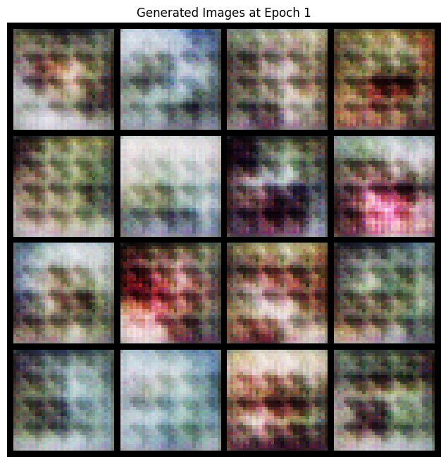

```
Epoch [2/20]  D Loss: 0.4179  G Loss: 4.0753
Epoch [3/20]  D Loss: 0.5004  G Loss: 3.2502
Epoch [4/20]  D Loss: 0.4519  G Loss: 3.1376
Epoch [5/20]  D Loss: 0.5932  G Loss: 2.8425
```

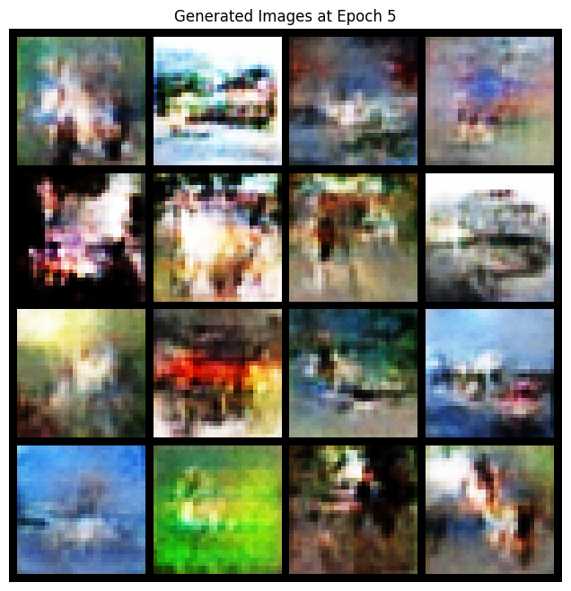

```
Epoch [6/20]  D Loss: 0.6493  G Loss: 2.4990
Epoch [7/20]  D Loss: 0.7558  G Loss: 2.2747
Epoch [8/20]  D Loss: 0.6660  G Loss: 2.2503
Epoch [9/20]  D Loss: 0.7111  G Loss: 2.3547
Epoch [10/20]  D Loss: 0.7402  G Loss: 2.2774
```

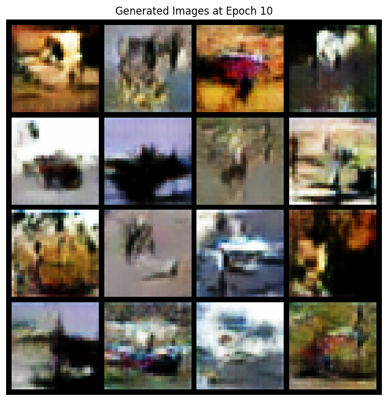

```
Epoch [11/20]  D Loss: 0.7675  G Loss: 2.0478
Epoch [12/20]  D Loss: 0.6827  G Loss: 2.1740
Epoch [13/20]  D Loss: 0.6964  G Loss: 2.2136
Epoch [14/20]  D Loss: 0.7778  G Loss: 2.0128
Epoch [15/20]  D Loss: 0.7618  G Loss: 1.9376
```

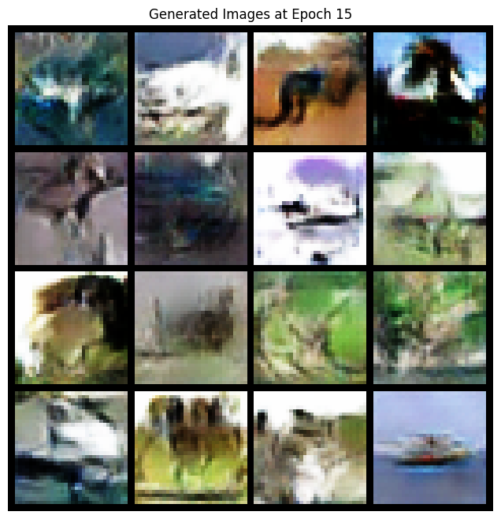

```
Epoch [16/20]  D Loss: 0.7764  G Loss: 1.8660
Epoch [17/20]  D Loss: 0.8036  G Loss: 1.8525
Epoch [18/20]  D Loss: 0.7989  G Loss: 1.8337
Epoch [19/20]  D Loss: 0.7900  G Loss: 1.8208
Epoch [20/20]  D Loss: 0.7910  G Loss: 1.8341
```

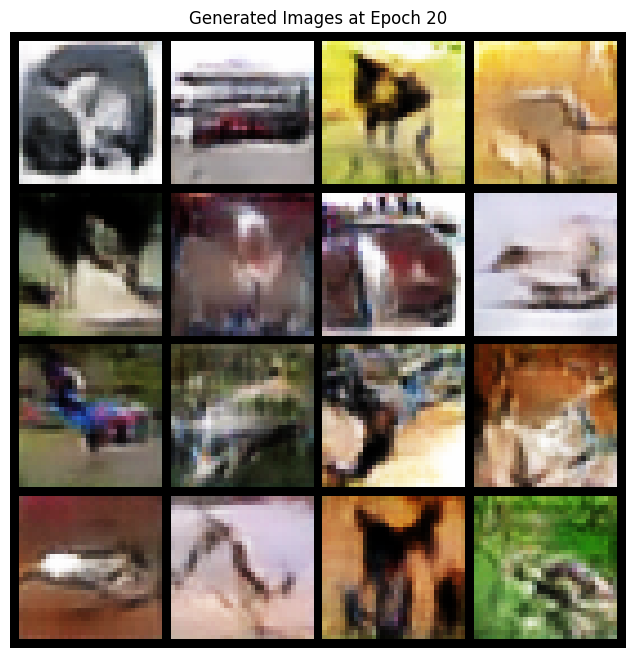

```python
# 17. Training Loop

g_losses = []
d_losses = []
fixed_noise = torch.randn(16, latent_dim, 1, 1, device=device)

for epoch in range(1, epochs + 1):
    running_g_loss = 0.0
    running_d_loss = 0.0

    for batch_idx, (real_images, _) in enumerate(train_loader):
        real_images = real_images.to(device)
        batch_len = real_images.size(0)

        real_labels = torch.ones(batch_len, 1, device=device)
        fake_labels = torch.zeros(batch_len, 1, device=device)

        # -----------------------------
        # Train Discriminator
        # -----------------------------
        discriminator.zero_grad()

        output_real = discriminator(real_images)
        d_loss_real = criterion(output_real, real_labels)

        noise = torch.randn(batch_len, latent_dim, 1, 1, device=device)
        fake_images = generator(noise)

        output_fake = discriminator(fake_images.detach())
        d_loss_fake = criterion(output_fake, fake_labels)

        d_loss = d_loss_real + d_loss_fake
        d_loss.backward()
        optimizer_D.step()

        # -----------------------------
        # Train Generator
        # -----------------------------
        generator.zero_grad()

        noise = torch.randn(batch_len, latent_dim, 1, 1, device=device)
        fake_images = generator(noise)
        output = discriminator(fake_images)

        g_loss = criterion(output, real_labels)
        g_loss.backward()
        optimizer_G.step()

        running_d_loss += d_loss.item()
        running_g_loss += g_loss.item()

    avg_d_loss = running_d_loss / len(train_loader)
    avg_g_loss = running_g_loss / len(train_loader)

    d_losses.append(avg_d_loss)
    g_losses.append(avg_g_loss)

    print(f"Epoch [{epoch}/{epochs}]  D Loss: {avg_d_loss:.4f}  G Loss: {avg_g_loss:.4f}")

    if epoch == 1 or epoch % 5 == 0 or epoch == epochs:
        show_generated_images(generator, epoch, latent_dim, device)
```

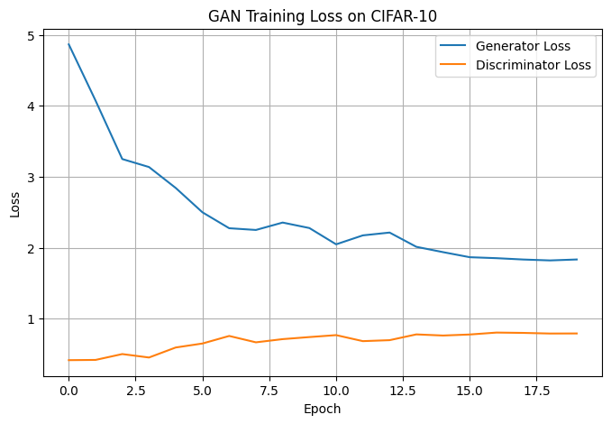

```python
# 18. Plot Training Loss Curves

plt.figure(figsize=(8, 5))
plt.plot(g_losses, label="Generator Loss")
plt.plot(d_losses, label="Discriminator Loss")
plt.xlabel("Epoch")
plt.ylabel("Loss")
plt.title("GAN Training Loss on CIFAR-10")
plt.legend()
plt.grid(True)
plt.show()
```

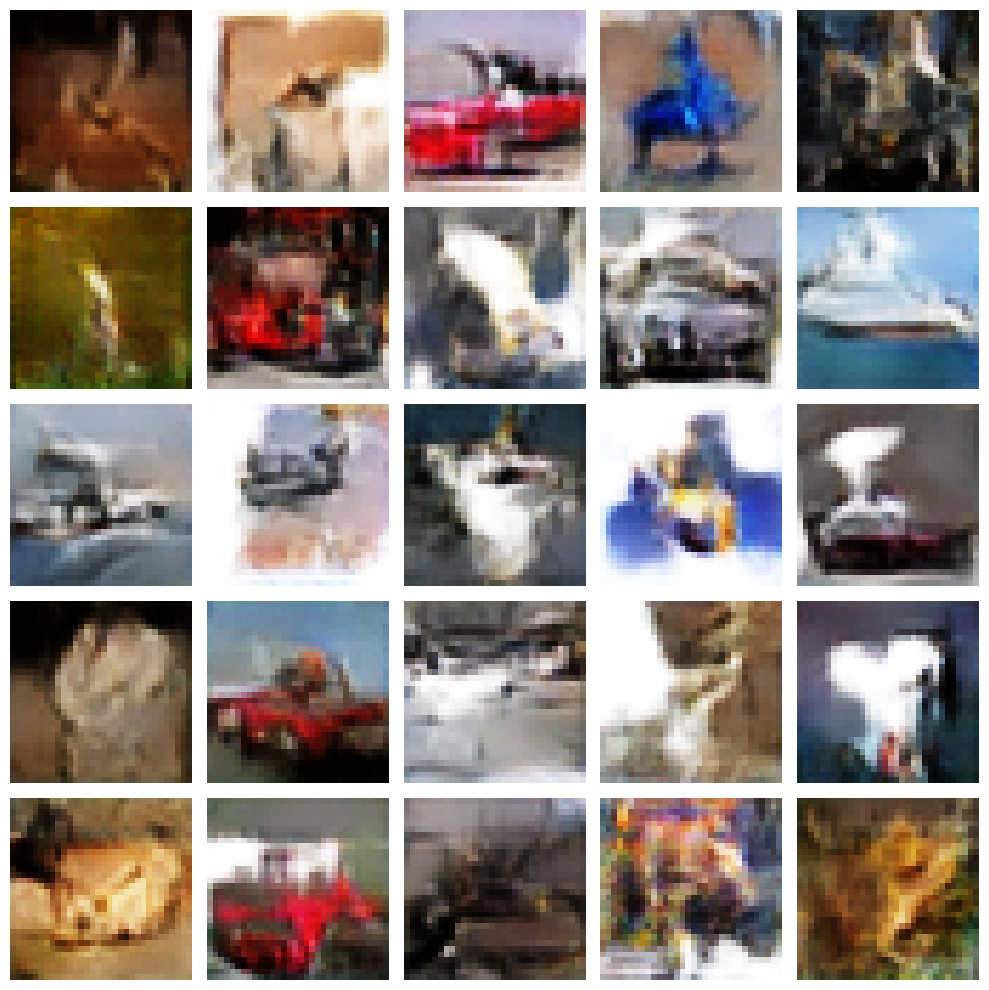

```python
# 19. Generate Final Synthetic Images

generator.eval()
with torch.no_grad():
    noise = torch.randn(25, latent_dim, 1, 1, device=device)
    generated_images = generator(noise).cpu()
    generated_images = generated_images * 0.5 + 0.5

fig, axes = plt.subplots(5, 5, figsize=(10, 10))
for i, ax in enumerate(axes.flatten()):
    img = generated_images[i].permute(1, 2, 0).numpy()
    ax.imshow(img)
    ax.axis("off")

plt.tight_layout()
plt.show()
```

```python
# 20. Save the Trained Generator Model

torch.save(generator.state_dict(), "generator_cifar10_gan.pth")
print("Saved as generator_cifar10_gan.pth")
```

```
Saved as generator_cifar10_gan.pth
```

# 10. Discussion and Analysis

## 10.1 What should students observe?

During training, students should observe:

- in early epochs, generated images may look noisy
- after several epochs, some structure may appear
- CIFAR-10 generation is difficult, so images may still be blurry
- Generator and Discriminator losses may fluctuate

## 10.2 Important GAN Challenges

### 1. Mode Collapse

The Generator may produce very similar images repeatedly.

### 2. Training Instability

GAN training is not always stable.  
Sometimes the Generator learns too fast, and sometimes the Discriminator becomes too strong.

### 3. Vanishing Gradient

If the Discriminator becomes perfect too early, the Generator may stop learning effectively.

### 4. Evaluation Difficulty

Unlike classification accuracy, GAN output quality is harder to measure numerically.

## 10.3 Why generated images may not look perfect?

Some reasons:

- training time is too short
- the model is simple
- CIFAR-10 is complex
- hyperparameters may need tuning
- GAN training is naturally unstable

### Part 9: Advantages, Disadvantages, and Applications of GANs

**Advantages:**

- Can generate realistic images, audio, text representations, and other data types.
- Useful for data augmentation when real data is limited.
- Can learn complex data distributions.
- Produces sharper images compared with some earlier generative models.

**Disadvantages:**

- Training is unstable and sensitive to hyperparameters.
- Mode collapse may occur, where the generator produces limited varieties of samples.
- Evaluation is difficult because there is no single perfect metric.
- Requires careful balance between generator and discriminator.

**Applications:**

- Image generation
- Image-to-image translation
- Super-resolution
- Data augmentation
- Face aging and editing
- Medical image synthesis
- Style transfer
- Anomaly detection

**Common GAN Variants:**

- **DCGAN:** Uses convolutional layers for image generation.
- **CGAN:** Conditional GAN that generates data based on labels or conditions.
- **CycleGAN:** Translates images between domains without paired data.
- **StyleGAN:** Generates highly realistic images with style-based control.
- **WGAN:** Improves training stability using Wasserstein loss.

### Final Lab Tasks

1. Explain the roles of the generator and discriminator in a GAN.
2. Write the mathematical objective function of GAN and explain each term.
3. Train the GAN for 2000, 5000, and 10000 epochs and compare the generated images.
4. Change the latent dimension from 100 to 50 and 200. Observe the effect.
5. Modify the generator by adding one more hidden layer and compare the result.
6. Explain mode collapse with an example.
7. Identify two real-world applications of GANs in computer vision.

### Part 11: Advantages, Disadvantages, and Applications of GANs

**Advantages:**

- Can generate realistic images, audio, text representations, and other data types.
- Useful for data augmentation when real data is limited.
- Can learn complex data distributions.
- Produces sharper images compared with some earlier generative models.

**Disadvantages:**

- Training is unstable and sensitive to hyperparameters.
- Mode collapse may occur, where the generator produces limited varieties of samples.
- Evaluation is difficult because there is no single perfect metric.
- Requires careful balance between generator and discriminator.

**Applications:**

- Image generation
- Image-to-image translation
- Super-resolution
- Data augmentation
- Face aging and editing
- Medical image synthesis
- Style transfer
- Anomaly detection

**Common GAN Variants:**

- **DCGAN:** Uses convolutional layers for image generation.
- **CGAN:** Conditional GAN that generates data based on labels or conditions.
- **CycleGAN:** Translates images between domains without paired data.
- **StyleGAN:** Generates highly realistic images with style-based control.
- **WGAN:** Improves training stability using Wasserstein loss.

### Final Lab Tasks

1. Explain the roles of the generator and discriminator in a GAN.
2. Write the mathematical objective function of GAN and explain each term.
3. Train the GAN for 2000, 5000, and 10000 epochs and compare the generated images.
4. Change the latent dimension from 100 to 50 and 200. Observe the effect.
5. Modify the generator by adding one more hidden layer and compare the result.
6. Explain mode collapse with an example.
7. Identify two real-world applications of GANs in computer vision.

Prepared By

**Md. Atikuzzaman**  
Lecturer  
Department of Computer Science and Engineering  
Green University of Bangladesh  
Email: atik@cse.green.edu.bd